# Reproducible Research Assignment

## Load Require Packages

```r
library(ggplot2)
library(scales)
library(data.table)
```

## Load and Process Data

### Download the file

```r
if(!file.exists("./data")){dir.create("./data")}
fileUrl <- "https://d396qusza40orc.cloudfront.net/repdata%2Fdata%2Factivity.zip"
download.file(fileUrl,destfile="./data/rep_data_activity.zip")
```

### Unzip dataSet to /data directory

```r
unzip(zipfile="./data/rep_data_activity.zip",exdir="./data")
```

### Read txt file in a variable applying filters.

```r
rawdata <- read.csv("./data/activity.csv", header=T, sep=',')
```

## mean total number of steps taken per day

### Mean total number of steps taken per day

```r
stepperday <- aggregate(rawdata$steps, by =list(rawdata$date), sum)
names(stepperday)[1] ="Date"
names(stepperday)[2] ="Total_Steps"
head(stepperday,5)
```

```
##         Date Total_Steps
## 1 2012-10-01          NA
## 2 2012-10-02         126
## 3 2012-10-03       11352
## 4 2012-10-04       12116
## 5 2012-10-05       13294
```

### Histogram of the total number of steps taken each day

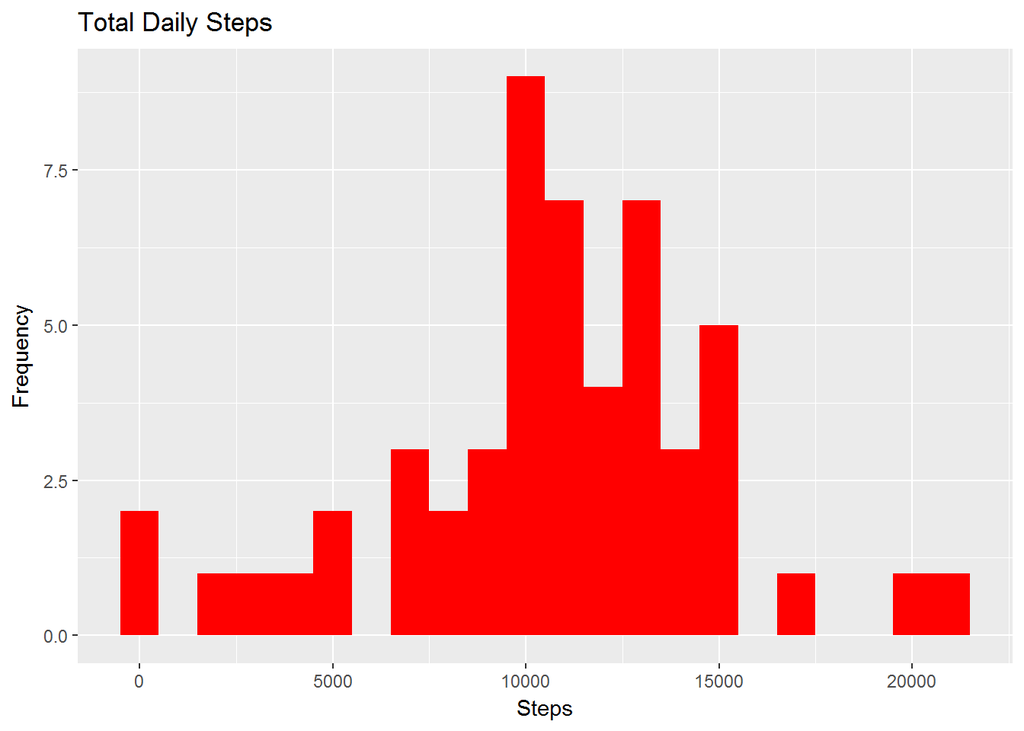

```r
ggplot(stepperday, aes(x = Total_Steps)) +
  geom_histogram(fill = "red", binwidth=1000) +
  labs(title = "Total Daily Steps", x = "Steps", y = "Frequency")
```

### Mean and median of the total number of steps taken per day

```r
mean(stepperday$Total_Steps, na.rm = TRUE)
```

```
## [1] 10766.19
```

```r
median(stepperday$Total_Steps, na.rm = TRUE)
```

```
## [1] 10765
```

## Average daily activity pattern

### time series plot of the 5-minute interval (x-axis) and the average number of steps taken, averaged across all days (y-axis)

[figure not shown]

```r
rawdataNA <- is.na(rawdata$steps)
cleandata <- rawdata[!rawdataNA,]
MeanDataByInterval <- aggregate(cleandata$steps, by=list(cleandata$interval), mean)
names(MeanDataByInterval)[1] ="interval"
names(MeanDataByInterval)[2] ="steps"

ggplot(MeanDataByInterval, aes(x = interval, y=steps)) +
  labs(title = "Sum of Steps by Interval", x = "interval", y = "steps")+
  geom_line(color="blue")
```

### Maximum Number of steps in 5-minute interval, on average across all the days in the dataset

```r
maxInterval <- MeanDataByInterval[which.max(MeanDataByInterval$steps),]
maxInterval
```

```
##     interval    steps
## 104      835 206.1698
```

## Imputing missing values

### Total number of missing values in the dataset

```r
missingVals <- sum(rawdataNA)
missingVals
```

```
## [1] 2304
```

### Strategy for filling in all of the missing values in the dataset.

### Use mean interval steps from Mean Steps for that interval.

### new dataset that is equal to the original dataset but with the missing data filled in

```r
# NA's in dataset
# dataset minus NA's for Mean calculation
rawdata1 <- rawdata
rawdata1NA <- rawdata1[is.na(rawdata1$steps),]
cleandata1 <- rawdata1[!is.na(rawdata1$steps),]

# generate Mean Data2 by interval
MeanData1ByInterval <- aggregate(cleandata1$steps, by=list(cleandata1$interval), sum)

names(MeanData1ByInterval)[1] ="interval"
names(MeanData1ByInterval)[2] ="steps"

# IMPUT METHOD

rawdata1 <- rawdata
missingData <- is.na(rawdata1$steps)
meanVals <- tapply(cleandata$steps, cleandata$interval, mean, na.rm=TRUE, simplify=TRUE)
rawdata1$steps[missingData] <- meanVals[as.character(rawdata1$interval[missingData])]
sum(missingData)
```

```
## [1] 2304
```

```r
# count of NA values
sum(is.na(rawdata1$steps))
```

```
## [1] 0
```

### histogram of the total number of steps taken each day and Calculate and report the mean and median total number of steps taken per day

```r
FullSummedDataByDay <- aggregate(rawdata1$steps, by=list(rawdata1$date), sum)

names(FullSummedDataByDay)[1] ="date"
names(FullSummedDataByDay)[2] ="totalsteps"
head(FullSummedDataByDay,10)
```

```
##          date totalsteps
## 1  2012-10-01   10766.19
## 2  2012-10-02     126.00
## 3  2012-10-03   11352.00
## 4  2012-10-04   12116.00
## 5  2012-10-05   13294.00
## 6  2012-10-06   15420.00
## 7  2012-10-07   11015.00
## 8  2012-10-08   10766.19
## 9  2012-10-09   12811.00
## 10 2012-10-10    9900.00
```

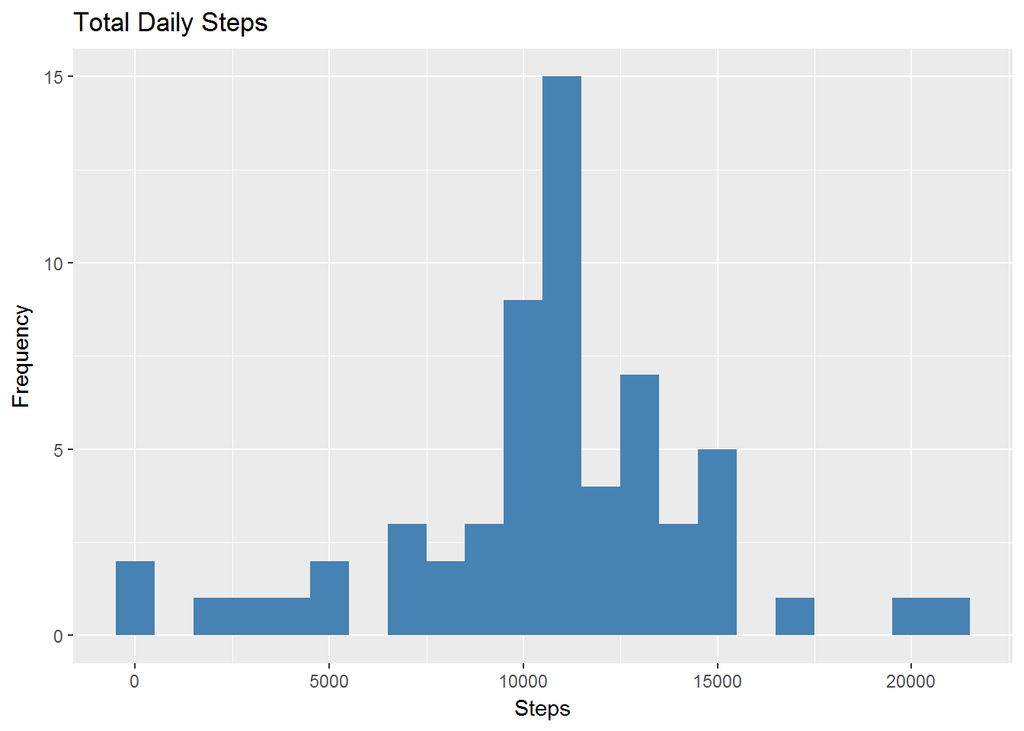

```r
# Plot using ggplot
ggplot(FullSummedDataByDay, aes(x = totalsteps)) +
  geom_histogram(fill = "steelblue", binwidth=1000) +
  labs(title = "Total Daily Steps", x = "Steps", y = "Frequency")
```

```r
# Mean on New Data
mean(FullSummedDataByDay$totalsteps)
```

```
## [1] 10766.19
```

```r
# Median on New Data
median(FullSummedDataByDay$totalsteps)
```

```
## [1] 10766.19
```

### Do these values differ from the estimates from the first part of the assignment

#### Yes, he mean is the same but the median has risen 1.19 steps.

#### Old Mean & Median

```r
mean(stepperday$Total_Steps, na.rm = TRUE)
```

```
## [1] 10766.19
```

```r
median(stepperday$Total_Steps, na.rm = TRUE)
```

```
## [1] 10765
```

#### New Mean and Median

```r
mean(FullSummedDataByDay$totalsteps)
```

```
## [1] 10766.19
```

```r
median(FullSummedDataByDay$totalsteps)
```

```
## [1] 10766.19
```

### Impact of imputing missing data on the estimates of the total daily number of steps

#### The effect of using mean data per interval as a data impute method for missing values seems to push overall data towards the mean.

```r
rawdata1$weekday <- weekdays(as.Date(rawdata1$date))
rawdata1$weekend <- ifelse (rawdata1$weekday == "Saturday" | rawdata1$weekday == "Sunday",  "Weekend", "Weekday")
#baseData2$weekend <- as.factor(baseData2$weekend)
head(rawdata1,5)
```

```
##       steps       date interval weekday weekend
## 1 1.7169811 2012-10-01        0  Monday Weekday
## 2 0.3396226 2012-10-01        5  Monday Weekday
## 3 0.1320755 2012-10-01       10  Monday Weekday
## 4 0.1509434 2012-10-01       15  Monday Weekday
## 5 0.0754717 2012-10-01       20  Monday Weekday
```

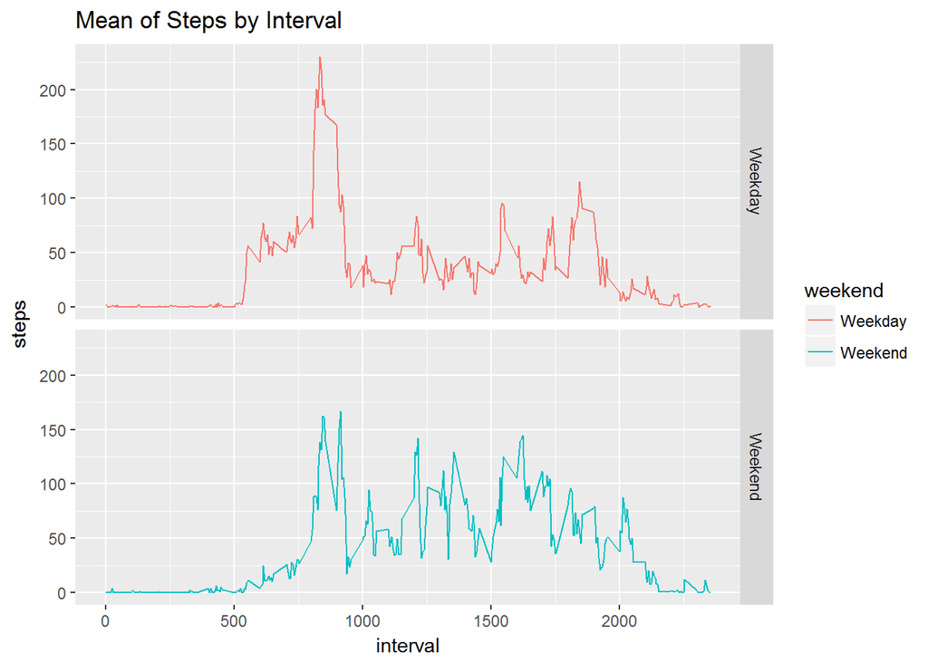

```r
Meandataweek <- aggregate(rawdata1$steps, by=list(rawdata1$weekend, rawdata1$interval), mean)
names(Meandataweek)[1] = "weekend"
names(Meandataweek)[2] = "interval"
names(Meandataweek)[3] = "steps"

ggplot(Meandataweek, aes(x = interval, y=steps, color=weekend)) +
  geom_line() +
  facet_grid(weekend ~ .) +
  labs(title = "Mean of Steps by Interval", x = "interval", y = "steps")
```